# Analysis 1: UNC Salaries

Sarah Bazari

July 01, 2025

# Instructions

**Overview:** For each question, show your R code that you used to answer each question in the provided chunks. When a written response is required, be sure to answer the entire question in complete sentences outside the code chunks. When figures are required, be sure to follow all requirements to receive full credit. Point values are assigned for every part of this analysis. **Do not work with other students on this assignment. You are to complete this assignment by yourself.**

**Helpful:** Make sure you knit the document as you go through the assignment. Check all your results in the created HTML file.

**Submission:** Submit via an electronic document on Canvas. Must be submitted as an HTML file generated in RStudio.

# Introduction

Universities are typically opaque, bureaucratic institutions. To be transparent to tax payers, many public schools, such as the University of North Carolina, openly report **[salary information](http://www.newsobserver.com/news/databases/public-salaries/)**. In this assignment, we will analyze this information from 2022 to answer pivotal questions that have endured over the course of time. This salary data for UNC-Chapel Hill faculty and staff was downloaded in CSV format and titled *“Salary Data Export.csv”*.

To answer all the questions, you will need the R package `tidyverse` to make figures and utilize `dplyr` functions.

# Data Information

Make sure the CSV data file is contained in the folder of your RMarkdown file. First, we start by using the `read_csv` function from the `readr` package found within the tidyverse. The code below executes this process by creating a tibble in your R environment named “salary”.

```r
salary=read_csv("Salary Data Export.csv")
```

Now, we will explore the information that is contained in this dataset. The code below provides the names of the variables contained in the dataset.

```r
names(salary)
```

```
##  [1] "University" "Last_Name"  "First_Name" "INIT"       "Age"
##  [6] "Hire_Date"  "Category"   "Salary"     "Department" "Title"
```

Next, we will examine the type of data contains in these different variables.

```r
str(salary,give.attr=F)
```

```
## spc_tbl_ [13,001 × 10] (S3: spec_tbl_df/tbl_df/tbl/data.frame)
##  $ University: chr [1:13001] "UNC-CH" "UNC-CH" "UNC-CH" "UNC-CH" ...
##  $ Last_Name : chr [1:13001] "Jin" "Tien" "McManus" "Rizvi" ...
##  $ First_Name: chr [1:13001] "Guifeng" "Hsiao-Chuan" "James" "Imran" ...
##  $ INIT      : chr [1:13001] NA NA "M" NA ...
##  $ Age       : num [1:13001] 61 58 60 47 53 35 66 46 44 40 ...
##  $ Hire_Date : chr [1:13001] "1/27/1997" "11/1/2008" "1/13/2020" "7/1/2018" ...
##  $ Category  : chr [1:13001] "IT Database Professional, Database Administrator" "IT Database Professional, Data Administrator" "Research Professional, Mathematics / Computing / Statistics" "Assistant Professor" ...
##  $ Salary    : num [1:13001] 99998 99998 99988 99988 99975 ...
##  $ Department: chr [1:13001] "Carolina Population Center" "Carolina Population Center" "Renaissance Computing Inst" "Biomedical Engineering-UG" ...
##  $ Title     : chr [1:13001] "Applications Analyst" "Applications Analyst" "Research Scientist" "Assistant Professor" ...
```

You will notice that the variable “Hire_Date” is recorded as a character. The following code will first modify the original dataset to change this to a date variable with the format *mm/dd/yyyy*. Then, we will remove the hyphens to create a numeric variable as *yyyymmdd*. Finally, in the spirit of tidyverse, we will convert this data frame to a tibble.

```r
salary$Hire_Date_Pre=as.Date(salary$Hire_Date, format="%m/%d/%Y")
salary$Hire_Date=as.numeric(gsub("-","",salary$Hire_Date_Pre))
salary=as_tibble(salary)
```

Now, we will use `head()` to view of first five rows and the modifications made to the original data. The rest of the assignment will extend off this modified dataset named `salary` which by now should be in your global environment.

```r
head(salary,5)
```

```
## # A tibble: 5 × 11
##   University Last_Name First_Name  INIT    Age Hire_Date Category         Salary
##   <chr>      <chr>     <chr>       <chr> <dbl>     <dbl> <chr>             <dbl>
## 1 UNC-CH     Jin       Guifeng     <NA>     61  19970127 IT Database Pro… 99998
## 2 UNC-CH     Tien      Hsiao-Chuan <NA>     58  20081101 IT Database Pro… 99998
## 3 UNC-CH     McManus   James       M        60  20200113 Research Profes… 99988
## 4 UNC-CH     Rizvi     Imran       <NA>     47  20180701 Assistant Profe… 99988.
## 5 UNC-CH     O'HARA    RICHARD     J        53  19931213 Research Profes… 99975
## # ℹ 3 more variables: Department <chr>, Title <chr>, Hire_Date_Pre <date>
```

# Assignment

## Part 1: Reducing the Data to a Smaller Set of Interest

### Q1 *(2 Points)*

Create a new dataset named `salary2` that only contains the following variables:

- “Last_Name”
- “First_Name”
- “Age”
- “Hire_Date”
- “Category”
- “Salary”
- “Department”

Then, use the `names()` function to display the variable names of `salary2`.

```r
salary2 = salary %>%
  select(Last_Name, First_Name, Age,
         Hire_Date, Category, Salary,
         Department)
names(salary2)
```

```
## [1] "Last_Name"  "First_Name" "Age"        "Hire_Date"  "Category"
## [6] "Salary"     "Department"
```

### Q2 *(2 Points)*

Now, we modify `salary2`. Rename the variables “Last_Name”,“First_Name”, and “Hire_Date” to “Last”,“First”, and “Hire”, respectively. Do this for a new dataset called `salary3` and use `names()` to display the variable names of `salary3`.

```r
salary3 = salary2 %>%
  rename(
    "Last" = "Last_Name",
    "First" = "First_Name",
    "Hire" = "Hire_Date"
  )
names(salary3)
```

```
## [1] "Last"       "First"      "Age"        "Hire"       "Category"
## [6] "Salary"     "Department"
```

### Q3 *(2 Points)*

Now, we modify `salary3`. Create a new variable called “HireYear” that only contains the first four digits of the variable “Hire” in a new dataset named `salary4`. Use the function `str()` to ensure that your new variable “HireYear” reports the year of the date that the employee was hired. **The variable “HireYear” should be numeric.**

```r
salary4 = salary3 %>%
  mutate(
    HireYear = as.numeric(substr(Hire, 1, 4)))

str(salary4$HireYear)
```

```
##  num [1:13001] 1997 2008 2020 2018 1993 ...
```

```r
# how do i make this numeric and prove its numeric?
```

### Q4 *(2 points)*

Now, we modify `salary4`. Create a new variable called “YrsEmployed” which reports the number of full years the employee has worked at UNC. Use the current year and assume that all employees are hired January 1. Create a new dataset named `salary5` and again use `str()` to display the variables in `salary5`.

```r
salary5 = salary4 %>%
  mutate(
    YrsEmployed = 2025 - HireYear
  )
str(salary5$YrsEmployed)
```

```
##  num [1:13001] 28 17 5 7 32 4 26 5 14 11 ...
```

### Q5 *(3 points)*

Now, we modify `salary5` to create our final dataset named `salary.final`. Use the pipe `%>%` to make the following changes:

- Drop the variables “Hire”, “HireYear”, “First”, and “Last”.
- Sort the observations first by “YrsEmployed” and then by “Salary”, both in ascending order from smallest to largest.
- Rearrange the variables so that “YrsEmployed” and “Salary” are the first two variables in the dataset, in that order, without removing any of the other variables.

After you have used the `%>%` to make these changes, use the function `head()` to display the first 12 rows of `salary.final`.

```r
salary.final = salary5 %>%
  subset(select = -c(Hire, HireYear, First, Last)) %>%
  arrange(YrsEmployed, Salary, descending = TRUE) %>%
  select("YrsEmployed", "Salary", everything()) # puts everything else after

head(salary.final, 12)
```

```
## # A tibble: 12 × 5
##    YrsEmployed Salary   Age Category                               Department
##          <dbl>  <dbl> <dbl> <chr>                                  <chr>
##  1           3  20500    32 Development / Fundraising Professional University D…
##  2           3  31200    24 Client Care Assistant                  TEACCH - CLLC
##  3           3  31200    28 Research Asst/Tech, Life Science       Comparative …
##  4           3  31200    31 Mail Carrier                           AS CM Campus…
##  5           3  31200    24 Research Asst/Tech, Life Science       Comparative …
##  6           3  31200    40 Client Care Assistant                  OBGYN-Horizo…
##  7           3  31846    55 Pest Control Worker                    FS-Grounds-L…
##  8           3  31846    27 Grounds / Landscape Worker             FS-Grounds-F…
##  9           3  31980    20 Grounds / Landscape Worker             FS-Grounds-L…
## 10           3  31980    20 Grounds / Landscape Worker             FS-Grounds-L…
## 11           3  32500    59 Research Asst/Tech, Social Science     FPG Child De…
## 12           3  32642    19 Grounds / Landscape Worker             FS-Grounds-L…
```

## Part 2: Answering Questions Based on All Data

In these questions,find the answer using code, and then answer the question using complete sentences below the code. I want to see your answer calculated/presented in your code output and in your writing.

### Q6 *(3 Points)*

What is the difference between the mean salary of employees in my department and the mean salary of employees in Economics?

Code *(2 Points)*:

```r
# pulling mean salary of my dep and econ dep
my_dep = salary.final %>%
  filter(Department == "Biology") %>%
  summarize(mean_salary = mean(Salary, na.rm = TRUE)) %>%
  pull(mean_salary)

econ_dep = salary.final %>%
  filter(Department == "Economics") %>%
  summarize(mean_salary = mean(Salary, na.rm = TRUE)) %>%
  pull(mean_salary)

# finding diff
diff_n_salary = abs(my_dep - econ_dep)
diff_n_salary
```

```
## [1] 65389.86
```

Answer *(1 Point)*: The difference in average salaries between the Biology Department and Economics Department is $65,389.86.

### Q7 *(3 Points)*

What proportion of all assistant professors make more than $90,000?

Code *(2 Points)*:

```r
over90 = salary.final %>%
  filter(Category == "Assistant Professor", Salary >= 90000) %>%
  nrow()

total = salary.final %>%
  filter(Category == "Assistant Professor") %>%
  nrow()

prop = over90 / total
prop
```

```
## [1] 0.759375
```

Answer *(1 Points)*: About 75% of all assistant professors make more than $90,000.

### Q8 *(5 Points)*

The categories “Instructor” and “Lecturer” represent employees who are primarily hired for teaching. For all the departments that have at least 3 employees who are primarily hired for teaching, I want you to calculate the total departmental spending for employees who are primarily hired for teaching. Of the departments with at least 3 instructors or lecturers, which department spends the most money for these teaching position and which department spends the least money for these teaching positions. I also want to know how many employees are primarily hired for teaching in each of these two departments. Your code output should show a table that shows the two departments, the number of employees hired for teaching, and the total spending.

Code *(4 Points)*:

```r
cat_tibble = salary.final %>%
  filter(Category %in% c("Instructor", "Lecturer")) %>%
  group_by(Department) %>%
  summarize(
    num_teachrole = n(), # count of those in teaching role
    spending = sum(Salary, na.rm = TRUE) # total salary spending
  ) %>%
  filter(num_teachrole >= 3) %>% # keeps departments w/ at least 3 employees in teaching role
  mutate(
    rank_spending = min_rank(spending) # need this rank column 1 = lowest, but interest in 3
  )

teaching_lownhigh = cat_tibble %>%
  filter(rank_spending == 3 | rank_spending == max(rank_spending)) %>%
  select(Department, num_teachrole, spending)

teaching_lownhigh
```

```
## # A tibble: 2 × 3
##   Department           num_teachrole spending
##   <chr>                        <int>    <dbl>
## 1 Anthropology                     3  163641
## 2 Psychiatry - General            27 1817758.
```

## Part 3: Answering Questions Based on Summarized Data

In general, it is not good to build an analysis off summarized data. Typically, you would want to analyze relationships and build models off your raw data where each observation is an individual. The future questions are based on summarized data. By doing this, I am unable to make inference or draw conclusions about the population of employees since each observation (row) is no longer a person. Think about this as you answer the following questions.

### Q9 *(4 Points)*

Based off the data in `salary.final`, create a grouped summary based off combinations of “Department” and “Category”. Call the new tibble `dept_cat_summary`. Your summarized tibble, `dept_cat_summary`, should report all of the following statistics with corresponding variable names in the following order.

- “n” = number of employees for each combination
- “salary” = average salary for each combination
- “yrs” = average years employed for each combination
- “age_vs_salary” = correlation between the age and salary for each combination

In the process, make sure you use `ungroup()` with the pipe `%>%` to release the grouping so future work is no longer group specific. Also, the `cor()` can be used to calculate the correlation between two variables.

Following the creation of `dept_cat_summary`, prove that your code showing the first 12 rows.

```r
dept_cat_summary = salary.final %>%
  group_by(Department, Category) %>%
  summarize(
    n = n(), # number of employees
    salary = mean(Salary, na.rm = TRUE),
    yrs = mean(YrsEmployed),
    # cor() automatic correlation b/w x, y and includes argument to get rid of NA vals
    age_vs_salary = cor(Age, Salary, use = "complete.obs")
  ) %>%
  ungroup()
head(dept_cat_summary, 12)
```

```
## # A tibble: 12 × 6
##    Department Category                              n salary   yrs age_vs_salary
##    <chr>      <chr>                             <int>  <dbl> <dbl>         <dbl>
##  1 AHEC       Accounting Professional, Dept Bu…     1 8.36e4 19           NA
##  2 AHEC       Administrative / Office / Cleric…     1 4.39e4  8           NA
##  3 AHEC       Administrative Assistant              2 4.94e4 10           -1
##  4 AHEC       Administrative Specialist / Coor…     2 1.48e5  9.5          1
##  5 AHEC       Communications / Marketing Profe…     1 5.32e4  7           NA
##  6 AHEC       Community Development Profession…     1 1.08e5 12           NA
##  7 AHEC       Executive Assistant                   1 5.47e4  3           NA
##  8 AHEC       Fiscal Affairs Paraprofessional       1 4.77e4 33           NA
##  9 AHEC       Functional Paraprofessional           1 6.24e4  4           NA
## 10 AHEC       IT (Information Technology) Prof…     3 1.13e5  9.67         0.529
## 11 AHEC       IT Applications Professional, Pr…     2 7.51e4 13           -1
## 12 AHEC       IT Database Professional, Data A…     1 1.12e5 11           NA
```

### Q10 *(4 Points)*

Using the summarized data in `dept_cat_summary`, which 5 “Department” and “Category” combinations have the strongest correlation between age and salary. Only consider “Department” and “Category” combinations that have at least 10 total employees. You can write as much code as you want, but your output should show a table (tibble or data frame) that only lists the “Department”, “Category”, and the “age_vs_salary” correlation for the 5 combinations you identified.

Code:

```r
combo_cor = dept_cat_summary %>%
  filter(n >= 10) %>%
  arrange(desc(abs(age_vs_salary))) %>% # we already arranged so we just want to select top 5
  slice_head(n = 5) %>% # slice() allows to select/remove/duplicate rows
  select(Department, Category, age_vs_salary)
combo_cor
```

```
## # A tibble: 5 × 3
##   Department             Category                            age_vs_salary
##   <chr>                  <chr>                                       <dbl>
## 1 Alcohol Studies Center Research Asst/Tech, Health/Medicine         0.940
## 2 Marsico Lung Institute Research Asst/Tech, Health/Medicine         0.902
## 3 Kenan-Flagler Bus Sch  Administrative Assistant                    0.880
## 4 Religious Studies      Associate Professor                         0.874
## 5 SA Carolina Housing    Student Housing Professional                0.873
```

### Q11 *(4 points)*

Create a scatter plot using `geom_point()` along with fitted linear regression lines using `geom_smooth` showing the linear relationship between average salary of Professors and the average years employed of Professors. Put the average years employed on the x-axis of your plot. **For this plot, use the summarized data in `dept_cat_summary` and exclude Departments where there are less than 5 professors.**

Following the plot, please explain what this plot suggests about the relationship between the average years employed and the average salary of professors. Make reference to the figure and use descriptive adjectives (i.e. “strong”, “weak”, etc.) and terms (i.e. “positive”, “negative”, etc.) that are appropriate for discussing linear relationships. When consulting the graphic, think about or research online what the shaded region around the regression line indicates.

Code and Figure *(2 Points)*:

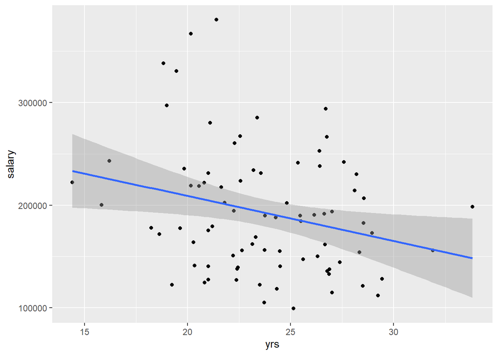

```r
exclusions = dept_cat_summary %>%
  filter(Category == "Professor", n >= 5)
# where professors and where departments w/ greater than 5

scatter = ggplot(data = exclusions, aes(
  x = yrs,
  y = salary
)) +
  geom_point() +
  geom_smooth(method = "lm", se= TRUE)
scatter
```

Answer *(2 Points)*: The regression line is sloping negatively which tells us there is a negative linear relationship between the average years employed and average salary. So, we might be able to conclude that departments where professors have been employed for longer have on average lower salaries. The spread of the points are dispersed somewhat widely, maybe suggesting a weak/moderate relationship strength. In general, we might expect the relationship to be the opposite, since we would assume working longer under a department would mean greater salaries (e.g. seniority). The shaded region around the regression line seems to be the confidence interval, which serves to represent the range of values for the true regression line. So, the actual regression line in blue is the best estimate of the relationship, and the shaded portion is the margin of error for the regression line estimate.

### Q12 *(4 Points)*

In `dept_cat_summary`, there are 750 unique departments. You can verify this by using `length(unique(dept_title_summary$Department))`. I want you to select only 3 academic departments not previously discussed or outputted in the assignment, and display the scatter plots and fitted linear regression lines representing the relationship between the average years employed and the average salary. Typically, the variable we would want to predict is on the y-axis, so assume that we want to predict the average salary. Use `facet_wrap` so that each department has its own figure. Remove the shading of the confidence intervals for the regression lines. **For this plot, use the summarized data in `dept_cat_summary`.**

Code and Figure:

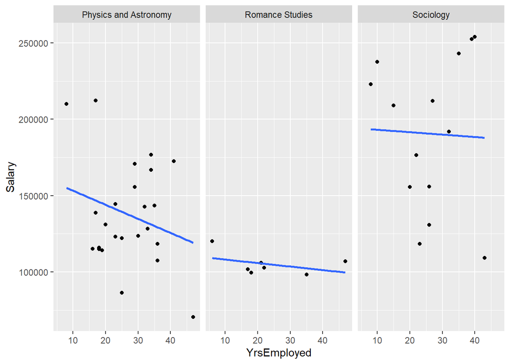

```r
num_unique_vals = length(unique(dept_cat_summary$Department))

selected_depts = salary.final %>%
  filter(Department %in% c("Sociology", "Romance Studies", "Physics and Astronomy"),
         Category == "Professor",
         !is.na(Salary),
         !is.na(YrsEmployed)
)

scatter_unique = ggplot(data = selected_depts, aes(x = YrsEmployed, y = Salary)) +
  geom_point() +
  geom_smooth(method = "lm", se = FALSE) + # this removes shading
  facet_wrap(~ Department)

scatter_unique  # theres no way to use dept_cat_summary to make this analysis b/c it has 1 row per group
```

### Q13 *(3 Points)*

Most academic departments have at least one employee in each of the three following categories: “Professor”,“Associate Professor”, and “Assistant Professor”. I want you to choose 3 academic departments that were not previously discussed and not used in your previous question (Q12). These 3 academic departments have to have at least one employee in each of the three categories mentioned. Then, I want you to construct a tile plot where “Department” is on the x-axis and “Category” is on the y-axis. The color of the tiles should be based off the average salary of all employees in each combination of “Department” and “Category”. In the tile, plot I only want to see the three departments you chose on the x-axis and the three categories I chose on the y-axis. I don’t want to see every job category. If you construct the plot and discover one or more of the tiles are blank since one or more of your departments is missing representation in one of the three job categories, then choose a different academic department. **The summarized data in `dept_cat_summary` will be helpful here.**

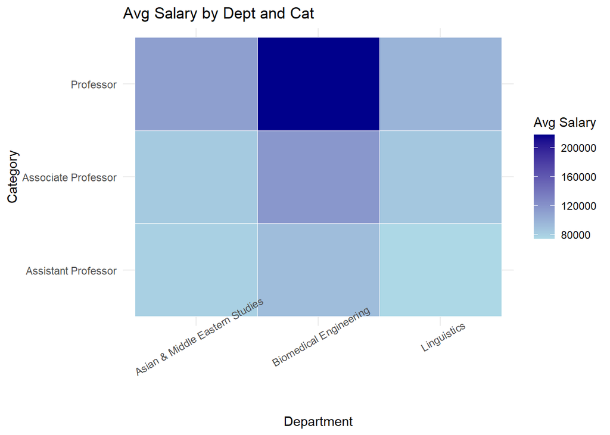

```r
# filter of what departments i need
# using this to find the departments that have atleast one employee in each of 3 cats
# the output are the departments i can choose from

specified_depts = dept_cat_summary %>%
  filter(Category %in% c("Professor", "Associate Professor", "Assistant Professor")) %>%
  group_by(Department) %>%
  summarize(num_cats = n_distinct(Category)) %>% # counts unique combos in vectors, kind of like nrow(unique)
  filter(num_cats == 3)

# filter data for 3 selections and 3 categories specified
# now im prepping for creation of tile plot
# filtering departments i chose with specifications
# i will use this data to create the tile plot
tile_prep = dept_cat_summary %>%
  filter(
    Department %in% c("Biomedical Engineering",
                      "Asian & Middle Eastern Studies",
                      "Linguistics"),
    Category %in% c("Professor", "Associate Professor", "Assistant Professor")
  )

# getting to the tile plot
tile_plot = ggplot(data = tile_prep, aes(x = Department, y = Category, fill = salary)) +
  geom_tile(color = "white") +
  scale_fill_gradient(low = "lightblue", high = "darkblue") +
  labs(
    title = "Avg Salary by Dept and Cat",
    fill = "Avg Salary"
  ) +
  theme_minimal() +
  theme(axis.text.x = element_text(angle = 30)) # ggplot2 stuff to make it look a lil better

tile_plot
```